# The Leaf Economic Spectrum

## The Leaf Economic Spectrum (LES)

- **The LES is a global framework describing a continuum of leaf traits from “fast” to “slow” strategies.**
  - “Fast” traits = cheap construction, rapid photosynthetic returns, short lifespan
  - “Slow” traits = expensive to make, durable, long-lived, conservative in resource use
- **It captures a trade-off between rapid resource acquisition and long-term survival**
- **The landmark paper synthesized global data from over 2,500 species across 175 sites to reveal consistent trade-offs among key leaf traits — lifespan, photosynthetic capacity, nitrogen content, and leaf thickness**
  - It established the LES as a unifying axis of variation in plant ecology

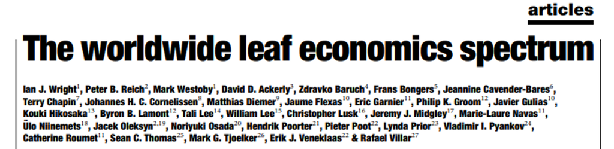

## What are functional traits?

- **Morphological, physiological, or phenological features measurable at the individual level**
- **Influence how an organism acquires resources, grows, reproduces, and survives in its environment**
  - most traits should be *subject* to natural selection
  - variation of a trait within an organism can also exist (plasticity)
- **Traits are often quantifiable and comparable across species**
- **Central to trait-based ecology, which uses traits instead of taxonomy to explain ecological patterns.**

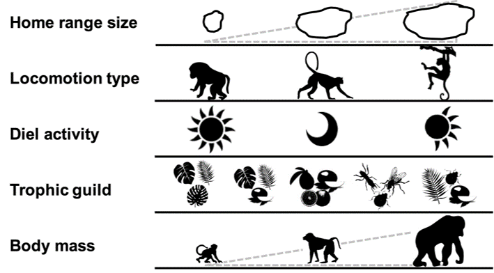

**What are the main plant functional traits?**

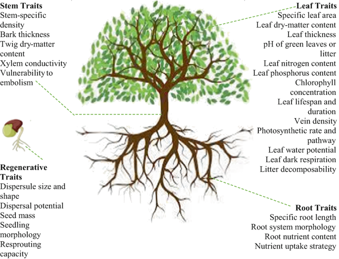

## LES: The Story of 4 Traits

- **Function of a leaf can be explored across key traits**
1. Leaf thickness
2. Nitrogen content
3. Leaf lifespan
4. Photosynthetic rate (umols CO<sub>2</sub> m<sup>-2</sup> s<sup>-1</sup>)
- **Traits are responsible for fixing carbon that contributes to growth, reproduction and survival**
  - total gain (lifespan), not instantaneous
- **Interplay between physiology, morphology and chemistry**

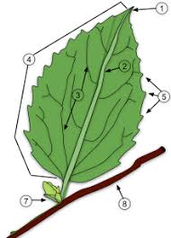

## Why does the LES matter?

- **Functional traits are comparable and predictive, more than species identity alone**
- **LES traits correlate with ecological strategies:**
  - Pioneer species (fast-return) dominate disturbed or high-light environments.
  - Climax species (slow-return) dominate resource-limited, stable environments.
- **Helps explain how plants partition resources across environments**
  - sun vs. shade
  - dry vs. wet
  - nutrient-rich vs. poor

[figure not shown]

## Leaf Thickness = Leaf Mass / Leaf Area (LMA)

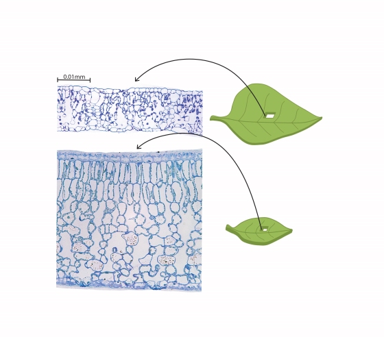

- **Leaf mass represents investment into construction**
  - photosynthetic machinery, water supply, etc.
- **Surface area vital in leaf making**
  - area exposed to light
  - drives photosynthesis & evaporative water loss
- **Variation in components of trait super variable**
  - large vs small area (magnolia vs spruce)
  - thin vs thick
  - across and within species
  - 14 to 1,500 g m<sup>2</sup>
- **?Why should every leaf not have large area?**
  - water loss, defense, mechanical support
  - environmental pressures

## Leaves need a lot of nitrogen (N)…

- **Vital structural and functional component of leaves:**
  - proteins, nucleic acids, ATP
  - co-enzymes NADP<sup>+</sup>,
  - pigments
  - 0.2 to 6.4% of total leaf mass
- **The greatest sink for nitrogen is Rubisco**
  - 20-30% of leaf nitrogen
- **Nitrogen needed for leaf persistence**
  - structural proteins in cell walls
  - herbivore defenses (secondary compounds)

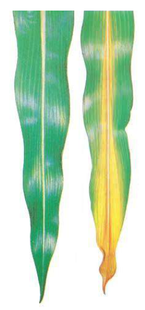

## Leaf Lifespan is more than just evergreen or deciduous

- **Leaf lifespan (LL) varies from few weeks to 25 years**
  - 0.9 to 288 months
- **Resources determine investment into leaf construction**
  - high resources = deciduous habitats
  - low resources = evergreen habitats
- **Photosynthesis decreases with leaf age**
  - photosynthetic machinery slowly breaks down
- **Trait strategy: ROI - return on investment…**
  - When to start over?
  - How much to/can invest in construction?

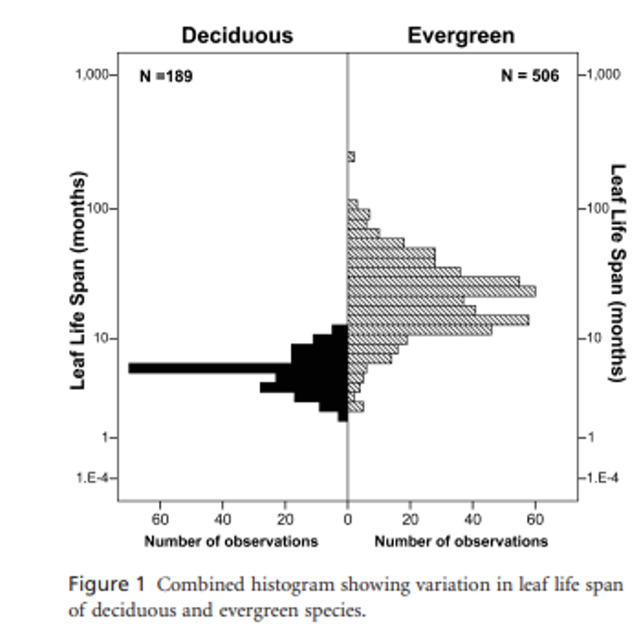

## What rate of photosynthesis can plants achieve?

- **You know the different pathways…**
- **You know that leaves need lots of ingredients**
- **Rates of photosynthesis vary dramatically**
  - ferns = 1 umols m<sup>-2</sup> sec<sup>-1</sup>
  - wheat = 25 umols m<sup>-2</sup> sec<sup>-1</sup>
  - both ferns and wheat use C3 pathway
  - often rates differ within a tree canopy
- **Why are rates so different?**

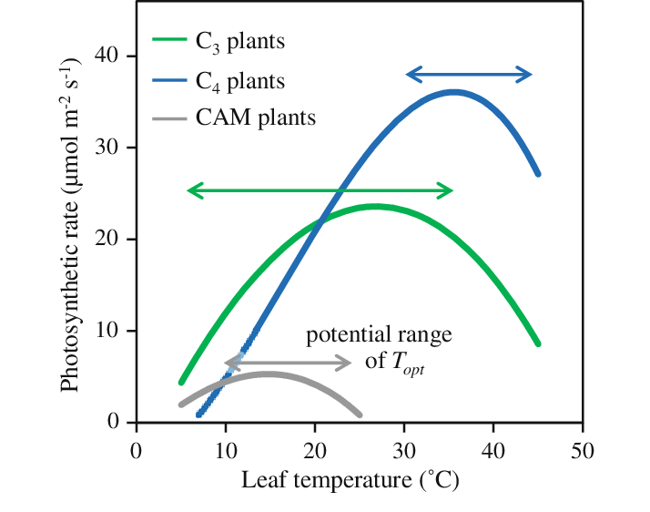

## Correlations among LES traits shared across plants

- **Vascular plants display patterns in relationships between LES traits**
  - all over the world
  - every habitat
- **Patterns are multi-dimensional**
  - LL vs LMA vs N vs Photo

**Example: A simple relationship between N and photosynthesis would ignore leaf lifespan**

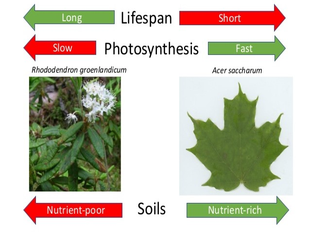

## Economic theory applied to plants

- **Leaf economics = revenues and expenditures per unit investment (ROI)**
- **Traits vary together and trade-off between acquiring and conserving resources**

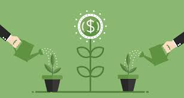

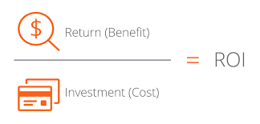

**Is the total ROI different between fast and slow return leaves over the leaf lifespan???**

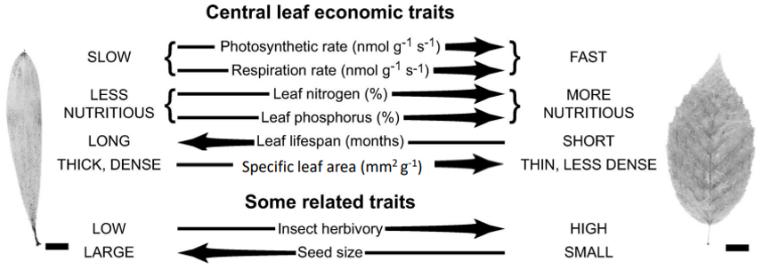

## Leaf nitrogen and thickness negatively correlated

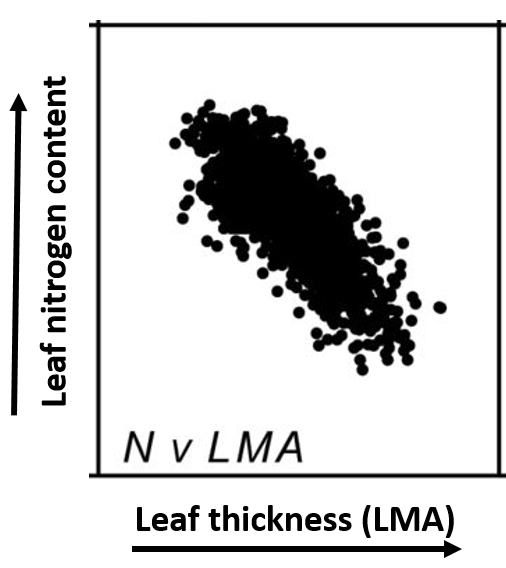

- **Increases in leaf N = optimized function**
  - N for Rubisco, chlorophyll
  - N for defense compounds
- **If N is high, why build expensive thick leaves?**
  - fast R.O.I.
- **Low leaf N = reduced function**
  - more invested in structural components (↑ thick)
  - slow R.O.I, durability higher

## Leaf Thickness and Leaf Lifespan Postively Correlated

- **Thickness reflects mass cost of deploying new leaf area**
  - thin leaves = cheaper
  - thin leaves if… R.O.I is fast
- **Leaf lifespan represents the duration of photosynthetic revenue**
  - the ‘return’ of R.O.I
- **Thin leaves = short leaf life span**
- **Thick leaves = long leaf life span**

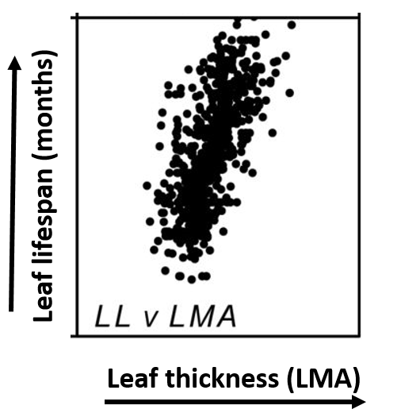

## These Relationships Regulate Photosynthesis

- **Decrease in LMA = Increase in photosynthesis rates**
  - usually high N but short lived
  - fast R.O.I
- **Long leaf lifespans = low photosynthesis rates**
  - usually thick leaf with low N
  - slow R.O.I
- **Environment plays a role:**
  - high N leaves are yummy to herbivores
  - leaf lifespan decreases during drought
- **Is this the same for all leaves on a plant?**

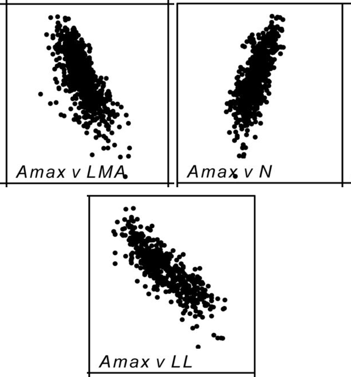

## Do Similar Trait Realtionships Exist for Whole Plants?

**Strategies for plant fitness also exist on a spectrum**

1. Seed production: coconut to orchid seed
2. Height: few cm to 115m
3. Woody to non-woody
4. Thick to thin leaves
5. Leaf area: fingernail to car hood
6. Leaf nitrogen investment across the canopy
- **Balances leaf construction costs against growth potential**
- **Size of whole plants and their parts**
- **Constrains evolution and qualifies plants for given environments**

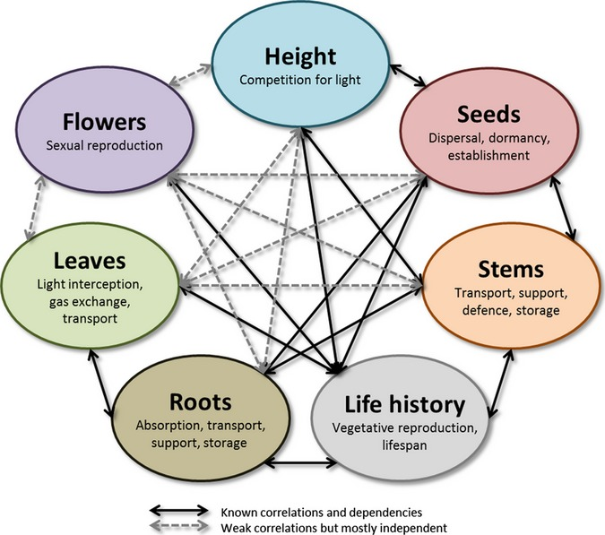

## Global Spectrum of Plant Form and Function (Diaz 2016)

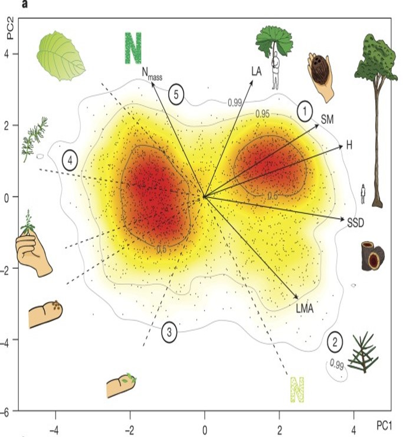

## Is the LES (THEORY) Perfect?

**2,500 = <1% of total described plant species. Some plant groups are underrepresented**

**Campany et al. 2021 - Epiphytic ferns show no relationships between N and LMA (orange circles)**

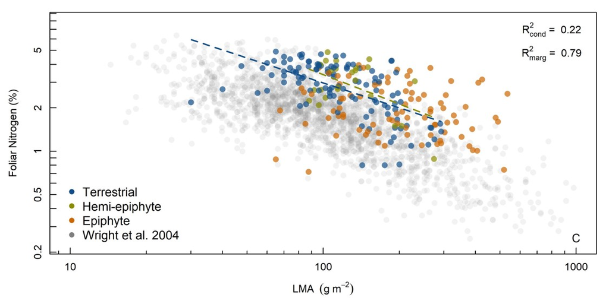